# Indel_analysis_Rmarkdown

Li Jiang

1/18/2018

## Introduction

The previous script “VariantCalling.py” scans through CIGAR strings in each file and outputs sizes and positions of indels, as well as sizes of deletion in the guide RNA, stored in a .csv file. It also reports a summary of total number of reads, mutations, deletions, insertions, unique indel patterns and frequency of mutations for subsequent analysis. This example shows analysis of Cpf1-induced indels in the target sequence of GFP.

## Data import

```r
csvFileNames = list.files(path="./data/", pattern = "*.csv")
sampleNames = c("WT_AGAT", "RR_AGAT", "RVR_AGAT", "WT_TTTA", "RR_TCCA", "RVR_TATT", "RR_ACCC",
                "RVR_TACA", "RVR_AATA", "Control_Control")
csvFileList = list()

for (i in 1:length(csvFileNames)){
  csvFileList[[i]] = read.csv(paste0("./data/",csvFileNames[i]),stringsAsFactors = F)
}
names(csvFileList) = sampleNames
pattern = "eGFP"
```

The raw .csv files for 10 different conditions are imported into a list. The list is named after the condition for each experiment. The characters before “_" denotes different Cpf1 variants while the characters after “_" denotes different direct repeat variants.

## A glimpse of the raw data

```r
## Check out top 15 most frequent indels
for (i in 1:length(csvFileList)){
  print(names(csvFileList)[i])
  print(head(sort(table(csvFileList[[i]][1]),decreasing=TRUE),15))
}
```

```
## [1] "WT_AGAT"
##
##  47M6D118M  47M4D118M  45M9D120M  43M6D122M 37M18D128M 34M21D131M
##       2565       1949       1610       1572       1366       1204
##  48M5D117M  44M1D121M  43M3D122M  48M3D117M 31M25D134M 44M10D121M
##        955        855        833        734        671        626
## 38M19D127M 38M25D127M 42M10D123M
##        621        600        575
## [1] "RR_AGAT"
##
##  47M6D118M  44M1D121M  47M4D118M 34M21D131M  45M9D120M  43M3D122M
##       5226       4571       2918       2866       2610       2516
##  44M4I117M  43M6D122M 37M18D128M  48M5D117M 38M25D127M  44M5I116M
##       2410       2092       1620       1417       1351       1327
##  45M3I117M 42M10D123M  45M4I116M
##       1246       1230       1157
## [1] "RVR_AGAT"
##
##  45M9D120M  47M6D118M  44M4I117M 37M18D128M  44M1D121M 42M10D123M
##       4663       3797       3174       2001       1931       1755
## 34M21D131M  46M2I117M  44M5I116M  43M6D122M  48M5D117M  46M3I116M
##       1471       1375       1326       1212       1175       1162
## 38M23D127M  43M3D122M 31M25D134M
##       1142       1104       1071
## [1] "WT_TTTA"
##
## 39M1D126M 30M1D135M  68M1D97M 56M1D109M 35M1D130M 47M1D118M  92M6D73M
##        90        39        28        21        20        20         7
## 44M1D121M 50M1D115M  71M1D94M  72M1D93M 28M1D137M 38M1D127M 42M1D123M
##         6         4         4         4         3         3         3
## 24M1D141M
##         2
## [1] "RR_TCCA"
##
##  69M7D96M 39M1D126M  68M1D97M 30M1D135M 47M1D118M 56M1D109M 35M1D130M
##       147        96        39        38        32        19        15
##  92M6D73M  72M1D93M 44M1D121M 26M2D139M 28M1D137M 26M1D139M 38M1D127M
##        13        10         7         5         5         4         3
## 46M1D119M
##         3
```

[output cut: 25 more lines]

```
##
## 39M1D126M  68M1D97M 30M1D135M 47M1D118M 35M1D130M 56M1D109M 44M1D121M
##        92        48        42        31        20        18         7
## 30M1I134M  92M6D73M 28M1D137M 59M1D106M 26M1D139M 26M2D139M 38M1D127M
##         6         6         5         5         4         3         3
##  71M1D94M
##         3
## [1] "Control_Control"
##
##     39M1D126M    118M30D47M    113M33D52M     30M1D135M      68M1D97M
##            48            46            31            22            22
##     47M1D118M     56M1D109M      92M6D73M     26M1D139M     46M1D119M
##            14            14             8             5             3
##     35M1D130M    42M10D123M     43M3D122M     45M9D120M 46M19I7M1I92M
##             2             2             2             2             2
```

The top 15 most frequent indels, represented as CIGAR strings are shown for each sample.

```r
## Top N most frequent indel size/position
indelTop = list(numeric(),numeric(),numeric())
indelTopFreq = list(numeric(),numeric(),numeric())
topN = 5

for (i in csvFileList){
  for (j in c(3:5)){
    temp = sort(table(i[,j]),decreasing=T)
    tempTop = names(temp)[1:topN]
    tempTopFreq = temp[tempTop]/sum(temp)
    indelTop[[j-2]] = c(indelTop[[j-2]], tempTop)
    indelTopFreq[[j-2]] = c(indelTopFreq[[j-2]], unname(tempTopFreq))
  }
}

sampleNameDf = rep(names(csvFileList),rep(topN,length(csvFileList)))
indelTopDf = data.frame(sampleNameDf, indelTop[[1]], indelTopFreq[[1]],
                        indelTop[[2]], indelTopFreq[[2]],
                        indelTop[[3]], indelTopFreq[[3]])
colnames(indelTopDf) = c("sample", "indel_size", "indel_size_freq",
                         "indel_position", "indel_position_freq",
                         "indel_size_in_guide",  "indel_size_in_guide_freq")
indelTopDf
```

```
##             sample indel_size indel_size_freq indel_position
## 1          WT_AGAT         -6     0.143699792             -2
## 2          WT_AGAT         -1     0.073759901              2
## 3          WT_AGAT         -4     0.065782821             -1
## 4          WT_AGAT         -9     0.063620021              3
## 5          WT_AGAT         -3     0.055109264              1
## 6          RR_AGAT         -6     0.104048900              3
## 7          RR_AGAT         -1     0.100706911             -2
## 8          RR_AGAT         -4     0.060627896              2
## 9          RR_AGAT         -3     0.057037433              1
## 10         RR_AGAT          4     0.052117628             -1
## 11        RVR_AGAT         -6     0.093534258             -2
## 12        RVR_AGAT         -9     0.081960318              2
## 13        RVR_AGAT          4     0.071503162              3
## 14        RVR_AGAT        -10     0.059581134              1
```

[output cut: 87 more lines]

Then the top 5 most frequent indel sizes and positions are shown for each sample. Deletions are shown as negative numbers while insertions are shown as positive numbers.

## Summary of total reads, mutations and frequency of mutations

```r
## Indel frequency
metaFileNames = list.files(path="./data/", pattern = "*.meta")
metaFileList = list()
metaCombined = NULL
## Read each meta file into a list and then combine into a single data frame
for (i in 1:length(csvFileList)){
  metaFileList[[i]] = read.csv(paste0("./data/",metaFileNames[i]),stringsAsFactors = F)
  metaCombined = rbind(metaCombined,metaFileList[[i]][1,])
}
colnames(metaCombined) = c("sumReads","sumMutations","sumDeletions","sumInsertions", "mutationFreq", "uniqueIndel")
metaCombined$sample = factor(names(csvFileList), level = names(csvFileList))
metaCombined$deletionFreq = metaCombined$sumDeletions/metaCombined$sumReads
metaCombined$insertionFreq = metaCombined$sumInsertions/metaCombined$sumReads
metaCombined
```

```
##    sumReads sumMutations sumDeletions sumInsertions mutationFreq
## 1    453502        34374        33023          2579  0.075796799
## 2    285420        78043        63335         17156  0.273432135
## 3    174665        67277        52604         16344  0.385177339
## 4    218764          287          281             6  0.001311916
## 5    297013          493          486             7  0.001659860
## 6    114300          124          121             3  0.001084864
## 7    255777          500          346           155  0.001954828
## 8    133849          150          149             3  0.001120666
## 9    251143          326          313            13  0.001298065
## 10   153220          257          252             6  0.001677327
##    uniqueIndel          sample deletionFreq insertionFreq
## 1          475         WT_AGAT  0.072817760  5.686855e-03
## 2          849         RR_AGAT  0.221901058  6.010791e-02
## 3          696        RVR_AGAT  0.301170813  9.357341e-02
## 4           40         WT_TTTA  0.001284489  2.742682e-05
## 5           60         RR_TCCA  0.001636292  2.356799e-05
## 6           29        RVR_TATT  0.001058618  2.624672e-05
## 7           80         RR_ACCC  0.001352741  6.059966e-04
## 8           34        RVR_TACA  0.001113195  2.241332e-05
## 9           41        RVR_AATA  0.001246302  5.176334e-05
## 10          48 Control_Control  0.001644694  3.915938e-05
```

The total number of reads, mutations, deletions, insertions, unique indel patterns as well as the frequency of mutations, deletions and insertions are summarized into a single data frame.

## Barplot of overall indel frequencies

```r
delIns = metaCombined[,c("deletionFreq", "insertionFreq", "sample")]
colnames(delIns) = c("Deletion", "Insertion", "Sample")
delIns = melt(delIns)
```

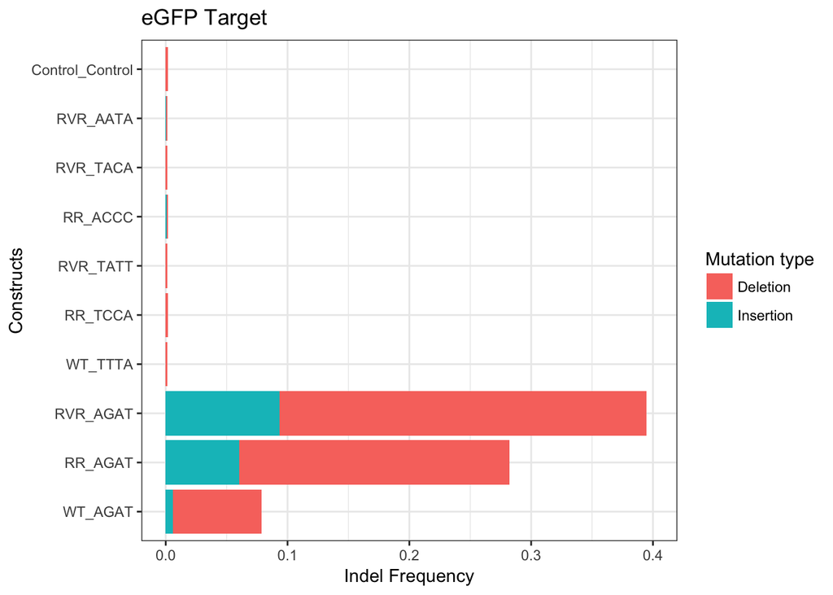

```r
ggplot(data=delIns,aes(x=Sample,y=value, fill=variable)) + geom_col() + coord_flip() + ggtitle(title) + ylim(0,0.4) +
        ylab ("Indel Frequency") + xlab("Constructs") + theme(plot.title = element_text(hjust = 0.5,face="bold",
        size=20), axis.text=element_text(size=10), axis.title=element_text(size=15,face="bold")) + theme_bw() +       guides(fill=guide_legend(title="Mutation type"))
```

## Total number of unique indels

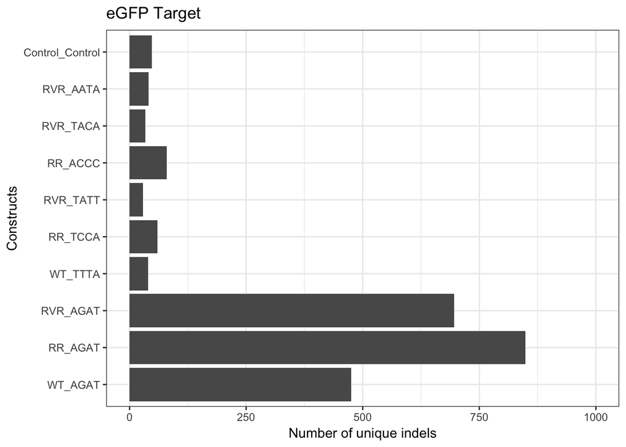

```r
ggplot(data=metaCombined,aes(x=sample,y=uniqueIndel)) + geom_col() + coord_flip() + ggtitle(title) + ylim(0,1000) +
        ylab ("Number of unique indels") + xlab("Constructs") + theme(plot.title = element_text(hjust = 0.5,
        face="bold", size=20), axis.text=element_text(size=10), axis.title=element_text(size=15,face="bold")) + theme_bw()
```

## Distribution of indel sizes

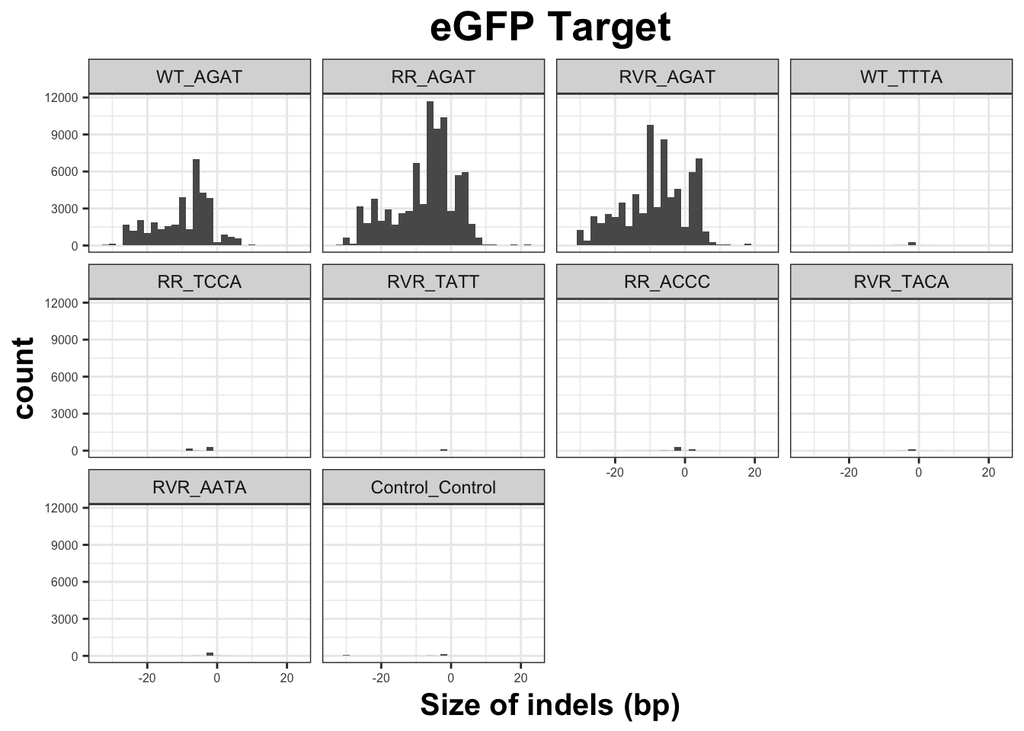

```r
## Histogram for indel size
ggplot(data=dataCombined, aes(size)) + geom_histogram() + facet_wrap(~sample) + ggtitle(title) + theme_bw() +
        theme(plot.title = element_text(hjust = 0.5,face="bold", size=20), axis.text=element_text(size=6),
              axis.title=element_text(size=15,face="bold")) + xlim(range(dataCombined$size)) +
              xlab("Size of indels (bp)")
```

The Most frequent sizes for deletions are 1, 3, 4, 6, 9, while the most frequent sizes for insertions are 4 (mostly observed in the two Cpf1 variants). The distribution appears to be consistent with reported patterns.

## Distribution of indel positions

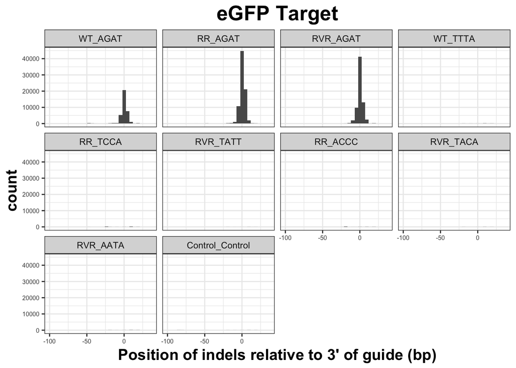

```r
## Histogram for indel position
ggplot(data=dataCombined, aes(position)) + geom_histogram() + facet_wrap(~sample) + ggtitle(title) + theme_bw() +
  theme(plot.title = element_text(hjust = 0.5,face="bold", size=20), axis.text=element_text(size=6),
        axis.title=element_text(size=15,face="bold")) + xlim(range(dataCombined$position)) +
        xlab("Position of indels relative to 3' of guide (bp)")
```

The indel position is computed as the distance from the mid point of indels to 3’ of the target sequence. For WT direct repeat, most indels lie at 1-3bp flanking 3’ of the target sequence, indicating that most indels occur at 3’ of the target sequence.

## Distribution of deletions in the guide RNA

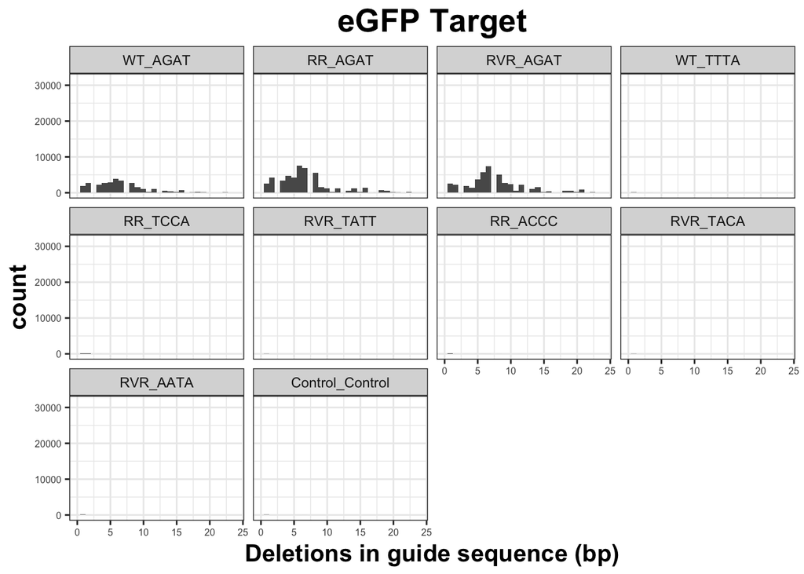

```r
ggplot(data=dataCombined, aes(delGuide)) + geom_histogram() + facet_wrap(~sample) + ggtitle(title) + theme_bw() +
  theme(plot.title = element_text(hjust = 0.5,face="bold", size=20), axis.text=element_text(size=6),
        axis.title=element_text(size=15,face="bold")) + xlim(range(dataCombined$delGuide)) +
        xlab("Deletions in guide sequence (bp)")
```

The most frequent sizes of deletions in the target sequence are 4-8 bases, indicating that most deletions result in partial deletions in the target sequence.

## Conclusion

Cpf1 is able to induce indels in the target of integrated GFP sequence in human leukemia cells, but it is not very instrumental as a system for CPRISPR-based evolving lineage tracing.